# Accelerometer Measured Activity Analysis

lytemar

# Purpose

The purpose of this document is to predict how well several people did barbell lifts using data from accelerometers on their belt, forearm, arm and dumbell in use. The participants were asked to perform barbell lifts correctly and incorrectly in 5 different ways. Thus, the goal is to train a model to predict which of the 5 different ways the exercise was performed.

# Data Reduction

The training and test sets contain raw data as well as summary statistics of the raw data. The summary statistics, average, variance, standard deviation, skewness, kurtosis, minimum, maximum, total and amplitude have been removed for modelling purposes as most of the entries of these summary columns are NA. Additionally, the various non-numeric features, such as the time stamps, X, new_window, and user_name have been removed as they are inconsequential to model formation. From this data reduction, the amount of columns in each data set is reduced from 160 to 49.

# Prediction Algorithm and Results

The build the prediction model, we center and scale the predictor variables to normalize them, then we feed them into a support vector machine (SVM) with radial basis functions and 10-fold cross-validation. Using SVM with cross-validation provides robust classification, and we know that the estimate of the out-of-sample error by computing the training error is quite a good estimate (see any statistical learning reference for proof). From this, we expect that the training error should be less that 10%, where more than 10% error would be a poor classifier in my humble opinion.

The figures below show the results of the model prediction giving the best final model:

```
## Support Vector Machines with Radial Basis Function Kernel
##
## 19622 samples
##    48 predictor
##     5 classes: 'A', 'B', 'C', 'D', 'E'
##
## Pre-processing: centered, scaled
## Resampling: Cross-Validated (10 fold)
##
## Summary of sample sizes: 17660, 17659, 17659, 17660, 17661, 17661, ...
##
## Resampling results across tuning parameters:
##
##   C     Accuracy  Kappa  Accuracy SD  Kappa SD
##   0.25  0.882     0.851  0.01167      0.0149
##   0.50  0.910     0.886  0.00938      0.0119
##   1.00  0.938     0.921  0.00936      0.0119
##
## Tuning parameter 'sigma' was held constant at a value of 0.01514675
## Accuracy was used to select the optimal model using  the largest value.
## The final values used for the model were sigma = 0.01514675 and C = 1.
```

```
## Support Vector Machine object of class "ksvm"
##
## SV type: C-svc  (classification)
##  parameter : cost C = 1
##
## Gaussian Radial Basis kernel function.
##  Hyperparameter : sigma =  0.0151467465812093
##
## Number of Support Vectors : 8768
##
## Objective Function Value : -1352.791 -921.6001 -821.468 -474.7481 -1261.222 -648.7032 -837.2371 -1326.594 -873.1818 -723.4524
## Training error : 0.054887
```

From these results, we obtain our estimate for the out-of-sample error listed as the training error (5.49%). Next, we plot the model fit to show how the training accuracy varies with the SVM penalty cost parameter, which is varied automatically by the SVM algorithm.

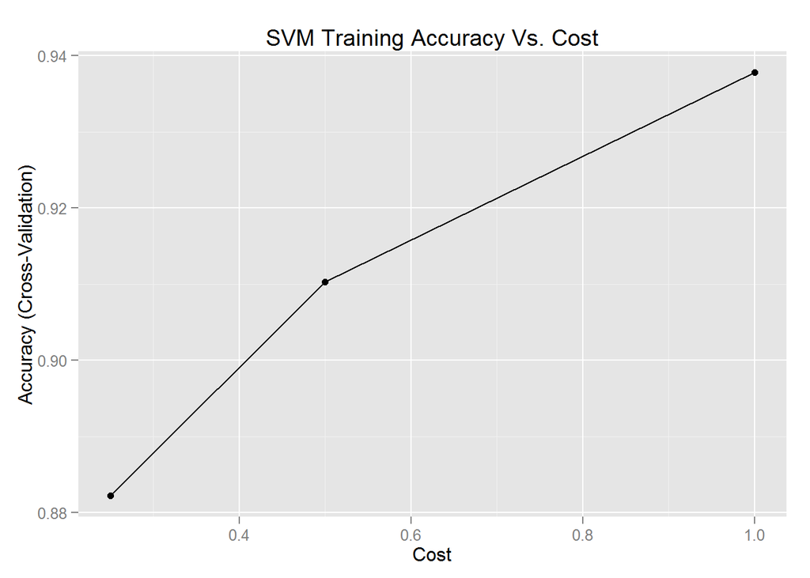

# Conclusion

In conclusion, we used SVM with radial basis function kernel and 10-fold cross-validation to obtain a classification prediction model that is highly accurate (93.8%) with a decent out-of-sample error (5.49%). We chose to compute the models by incorporating all subjects into one group because that provided a larger training set, which provides a lower in-sample error, and via cross-validation, a lower out-of-sample error. Finally, we could have used linear discriminant analysis or random forests as prediction algorithms, but it is current thinking that SVM is more mathematically robust between the three, so we chose SVM with good results.